# Main File for part II of basal attributes article

Author

Julius Fenn

# prepare data

## set up data.frame questionnaires

```r
setwd("outputs")
# > pre study
suppressMessages(read_file('preCAM.txt') %>%
                   # ... split it into lines ...
                   str_split('\n') %>% first() %>%
                   # ... filter empty rows ...
                   discard(function(x) x == '') %>%
                   discard(function(x) x == '\r') %>%
                   # ... parse JSON into a data.frame
                   map_dfr(fromJSON, flatten=TRUE)) -> dat_preCAM
# > post first CAM
suppressMessages(read_file('postCAM.txt') %>%
                   # ... split it into lines ...
                   str_split('\n') %>% first() %>%
                   # ... filter empty rows ...
                   discard(function(x) x == '') %>%
                   discard(function(x) x == '\r') %>%
                   # ... parse JSON into a data.frame
                   map_dfr(fromJSON, flatten=TRUE)) -> dat_postCAM


########################################
# create counter variable for both data sets
########################################
### pre study
dat_preCAM$ID <- NA

tmp_IDcounter <- 0
for(i in 1:nrow(dat_preCAM)){
  if(!is.na(dat_preCAM$sender[i]) && dat_preCAM$sender[i] == "Greetings"){
    # tmp <- dat_preCAM$prolific_pid[i]
    tmp_IDcounter = tmp_IDcounter + 1
  }
  dat_preCAM$ID[i] <- tmp_IDcounter
}



### post study
dat_postCAM$ID <- NA

tmp_IDcounter <- 0
for(i in 1:nrow(dat_postCAM)){
  if(!is.na(dat_postCAM$sender[i]) && dat_postCAM$sender[i] == "CAMfeedbackGeneral"){
    # tmp <- dat_postCAM$prolific_pid[i]
    tmp_IDcounter = tmp_IDcounter + 1
  }
  dat_postCAM$ID[i] <- tmp_IDcounter
}



########################################
# keep only complete data sets
########################################
### pre-study
# sort(table(dat_preCAM$ID))
sum(table(dat_preCAM$ID) != max(table(dat_preCAM$ID)))
```

```
[1] 0
```

```r
sum(table(dat_preCAM$ID) == max(table(dat_preCAM$ID)))
```

```
[1] 10
```

```r
dat_preCAM <- dat_preCAM[dat_preCAM$ID %in% names(table(dat_preCAM$ID))[table(dat_preCAM$ID) == max(table(dat_preCAM$ID))],]

### post-study
# sort(table(dat_postCAM$ID))
sum(table(dat_postCAM$ID) != max(table(dat_postCAM$ID)))
```

```
[1] 0
```

```r
sum(table(dat_postCAM$ID) == max(table(dat_postCAM$ID)))
```

```
[1] 10
```

```r
dat_postCAM <- dat_postCAM[dat_postCAM$ID %in% names(table(dat_postCAM$ID))[table(dat_postCAM$ID) == max(table(dat_postCAM$ID))],]



########################################
# json (from JATOS) to 2D data.frame
########################################
################################ pre-study
### add paradata
tmp_notNumeric <- str_subset(string = colnames(dat_preCAM), pattern = "^meta|^R")
tmp_notNumeric <- str_subset(string = tmp_notNumeric, pattern = "labjs|location", negate = TRUE)

### get survey
vec_ques <- c("PROLIFIC_PID",
              "dummy_informedconsent",
              "commCheck",
              tmp_notNumeric)

vec_notNumeric = c("PROLIFIC_PID", tmp_notNumeric)

questionnaire_preCAM <- questionnairetype(dataset = dat_preCAM,
                                        listvars = vec_ques,
                                        notNumeric = vec_notNumeric, verbose = FALSE)


dim(questionnaire_preCAM)
```

```
[1] 10 17
```

```r
################################ post-study
vec_ques <- c("PROLIFIC_PID", "commCheck",
              "feedCAM_repres", "feedCAM_technicalprobsText", "feedCAM_alreadyText",
              "openQuestion_MaterialSystem",
              "openQuestion_Ethic",
              "openQuestion_missedPositive", "openQuestion_missedNegative",
              "outcome_research", "outcome_prohibition", "outcome_buy", "outcome_buy_text",
              "education", "experienceMS",
              "feedback_critic")

vec_notNumeric = c("PROLIFIC_PID",
                   "feedCAM_technicalprobsText", "feedCAM_alreadyText",
                                 "openQuestion_MaterialSystem",
                                 "openQuestion_Ethic",
              "openQuestion_missedPositive", "openQuestion_missedNegative",
   "outcome_research", "outcome_prohibition", "outcome_buy", "outcome_buy_text",
                   "education", "experienceMS",
                   "feedback_critic")

questionnaire_postCAM <- questionnairetype(dataset = dat_postCAM,
                                        listvars = vec_ques,
                                        notNumeric = vec_notNumeric, verbose = FALSE)

questionnaire_postCAM$feedback_critic[questionnaire_postCAM$feedback_critic == ""] <- NA
dim(questionnaire_postCAM)
```

```
[1] 10 16
```

```r
questionnaire_postCAM$multipleEthic <- NA
tmp_multipleEthic <- cbind(dat_postCAM$ID, dat_postCAM$multipleEthic)

questionnaire_postCAM$multiplePositive <- NA
tmp_multiplePositive <- cbind(dat_postCAM$ID, dat_postCAM$multiplePositive)

questionnaire_postCAM$multipleNegative <- NA
tmp_multipleNegative <- cbind(dat_postCAM$ID, dat_postCAM$multipleNegative)


for(i in questionnaire_postCAM$ID){
  # add multipleEthic
  tmp <- tmp_multipleEthic[tmp_multipleEthic[,1] == i, ]
  if(length(unlist(tmp[,2])) == 3){
    questionnaire_postCAM$multipleEthic[questionnaire_postCAM$ID == i] <- paste0(unlist(tmp[,2]), collapse = " \\ ")
  }

  # add multiplePositive
    tmp <- tmp_multiplePositive[tmp_multiplePositive[,1] == i, ]
  if(length(unlist(tmp[,2])) == 3){
    questionnaire_postCAM$multiplePositive[questionnaire_postCAM$ID == i] <- paste0(unlist(tmp[,2]), collapse = " \\ ")
  }

      # add multipleNegative
    tmp <- tmp_multipleNegative[tmp_multipleNegative[,1] == i, ]
  if(length(unlist(tmp[,2])) == 3){
    questionnaire_postCAM$multipleNegative[questionnaire_postCAM$ID == i] <- paste0(unlist(tmp[,2]), collapse = " \\ ")
  }
}


dim(questionnaire_postCAM)
```

```
[1] 10 19
```

```r
################################ merge two data sets
questionnaire_postCAM$ID <- NULL
questionnaire <- left_join(questionnaire_preCAM, questionnaire_postCAM, by="PROLIFIC_PID")
dim(questionnaire)
```

```
[1] 10 34
```

## set up CAM data

### pre

Load CAM data

```r
setwd("outputs")
suppressMessages(read_file("CAMdata.txt") %>%
  # ... split it into lines ...
  str_split('\n') %>% first() %>%
    discard(function(x) x == '') %>%
    discard(function(x) x == '\r') %>%
  # ... filter empty rows ...
  discard(function(x) x == '')) -> dat_CAM_pre

raw_CAM <- list()
for(i in 1:length(dat_CAM_pre)){
  raw_CAM[[i]] <- jsonlite::fromJSON(txt = dat_CAM_pre[[i]])
}
```

Create CAM files, draw CAMs and compute network indicators

```r
########################################
# create CAM single files (nodes, connectors, merged)
########################################
CAMfiles <- create_CAMfiles(datCAM = raw_CAM, reDeleted = TRUE)
```

```
Nodes and connectors, which were deleted by participants were removed.
 # deleted nodes:  0
 # deleted connectors:  15
```

```r
## remove white spaces within pre-defined concepts
CAMfiles[[1]]$text <- str_replace_all(string = CAMfiles[[1]]$text, "\\s+", " ")

########################################
# draw CAMs
########################################
CAMdrawn <- draw_CAM(dat_merged = CAMfiles[[3]],
                     dat_nodes = CAMfiles[[1]],ids_CAMs = "all",
                     plot_CAM = FALSE,
                     useCoordinates = TRUE,
                     relvertexsize = 3,
                     reledgesize = 1)
```

```
processing 10 CAMs...
[1] "== participantCAM in drawnCAM"
```

```r
########################################
# draw CAMs
########################################
tmp_microIndicator <- V(CAMdrawn[[1]])$label # all concepts are pre-defined
networkIndicators <- compute_indicatorsCAM(drawn_CAM = CAMdrawn,
                                           micro_degree = tmp_microIndicator,
                                           micro_valence = tmp_microIndicator,
                                           micro_centr_clo = tmp_microIndicator,
                                           micro_transitivity = tmp_microIndicator,
                                           largestClique = FALSE)


########################################
# wordlists
########################################
CAMwordlist <- create_wordlist(
  dat_nodes =  CAMfiles[[1]],
  dat_merged =  CAMfiles[[3]],
  order = "alphabetic",
  splitByValence = FALSE,
  comments = TRUE,
  raterSubsetWords = NULL,
  rater = FALSE
)
```

```
processing 10 CAMs...
[1] "== participantCAM in drawnCAM"
```

```r
DT::datatable(CAMwordlist, options = list(pageLength = 5))
```

|  | Words | raw | percent | mean_valence | sd_valence | mean_degree | sd_degree | comment_1 | comment_2 |
| --- | --- | --- | --- | --- | --- | --- | --- | --- | --- |
| 5 | aktive Formänderung durch Umwelteinwirkung | 10 | 100 | -0.2 | 1.135292424395093 | 1.4 | 0.9660917830792959 |  |  |
| 6 | aktive Verhaltensänderung durch Umwelteinwirkung | 10 | 100 | 0.3 | 1.251665557034572 | 1.3 | 0.6749485577105528 |  |  |
| 1 | Akzeptanz eines neuen Materialsystems | 10 | 100 | 0.1 | 0.3162277660168379 | 15.8 | 11.19325193538003 |  |  |
| 7 | autonom | 10 | 100 | 0.7 | 1.159501808728406 | 1.1 | 0.3162277660168379 |  |  |
| 8 | bioinspiriert | 10 | 100 | 0.9 | 0.5676462121975467 | 2 | 0.9428090415820634 |  |  |
| 9 | elektronikfrei | 10 | 100 | 0.4 | 0.5163977794943222 | 1.3 | 0.4830458915396479 | kommt auf den Nutzen an |  |
| 2 | Energie generierend | 10 | 100 | 1.7 | 0.9486832980505138 | 1.9 | 1.286683937707919 |  |  |
| 3 | Energie speichernd | 10 | 100 | 1.8 | 0.7888106377466155 | 1.3 | 0.6749485577105528 |  |  |
| 10 | energieautonom | 10 | 100 | 1.7 | 1.159501808728406 | 1.5 | 0.8498365855987975 |  |  |
| 11 | energieeffizient | 10 | 100 | 1.8 | 0.7888106377466155 | 1.6 | 1.07496769977314 |  |  |

[output cut: 23 more lines]

### plot CAMs using igraph package

Just plot first 10 CAMs for an impression

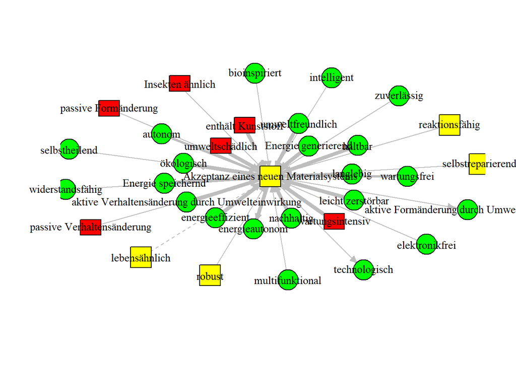

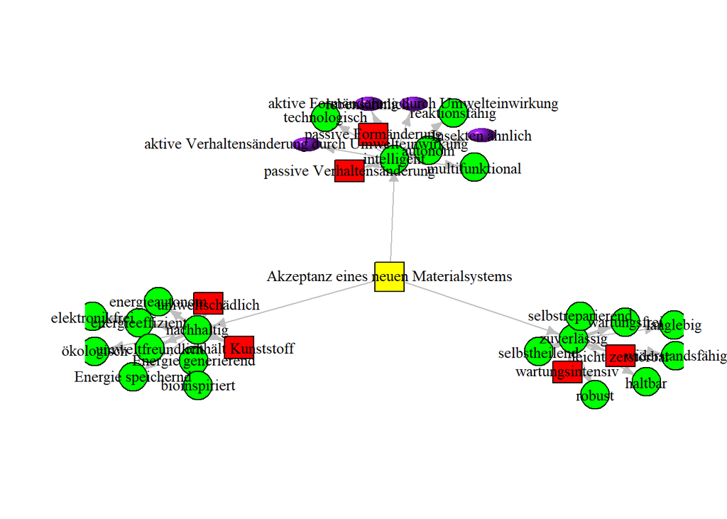

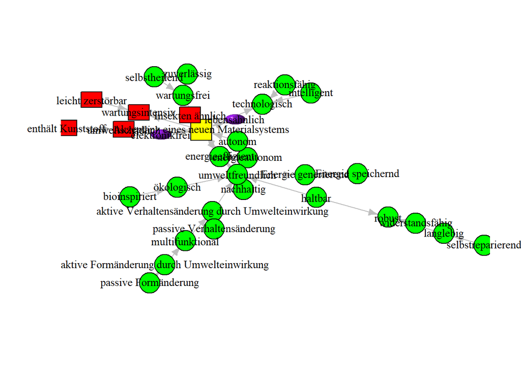

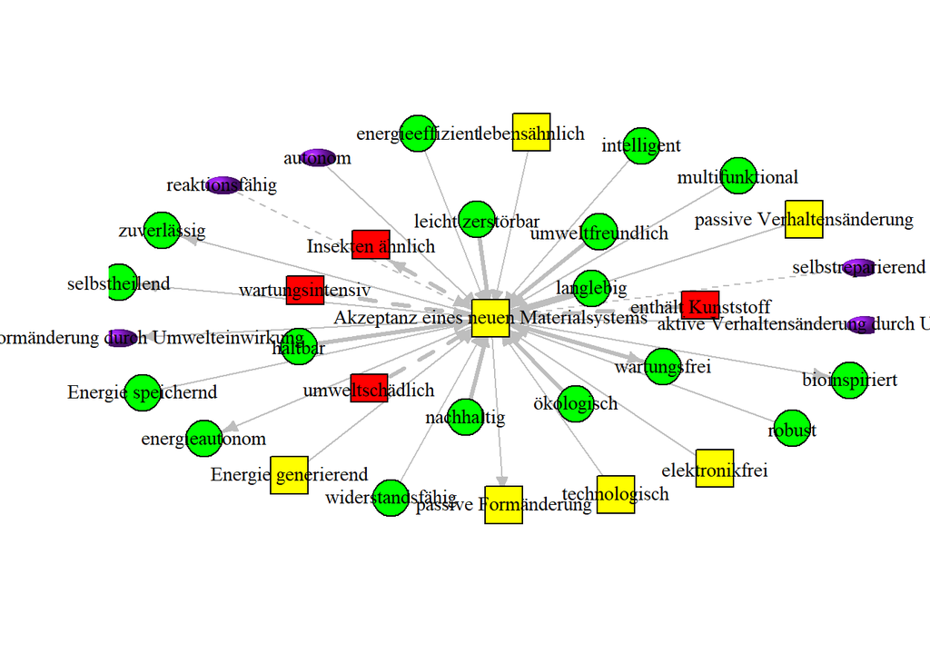

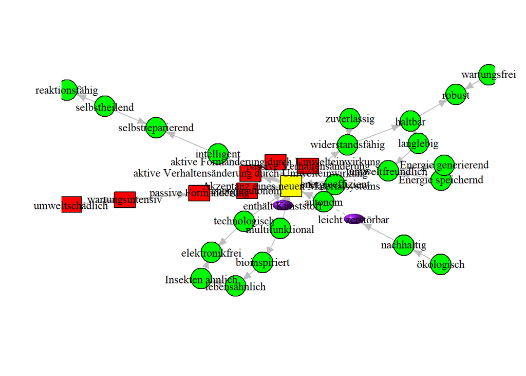

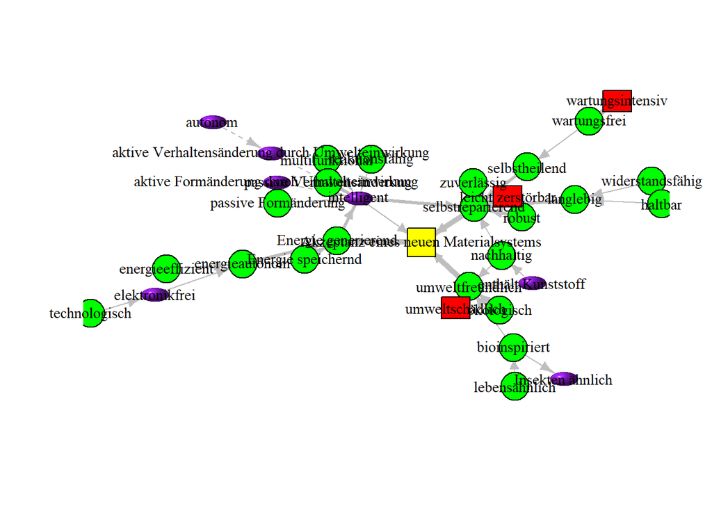

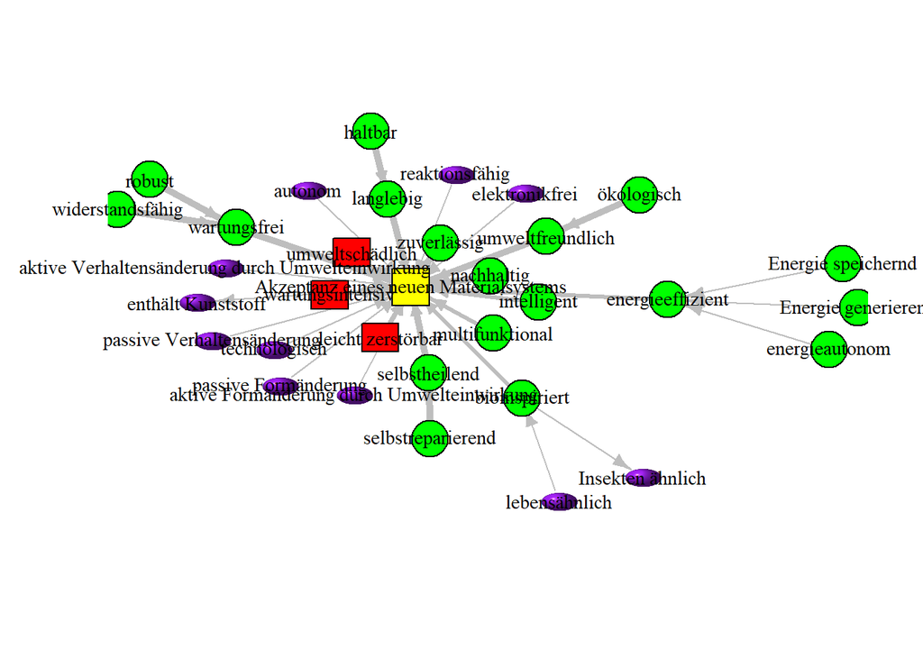

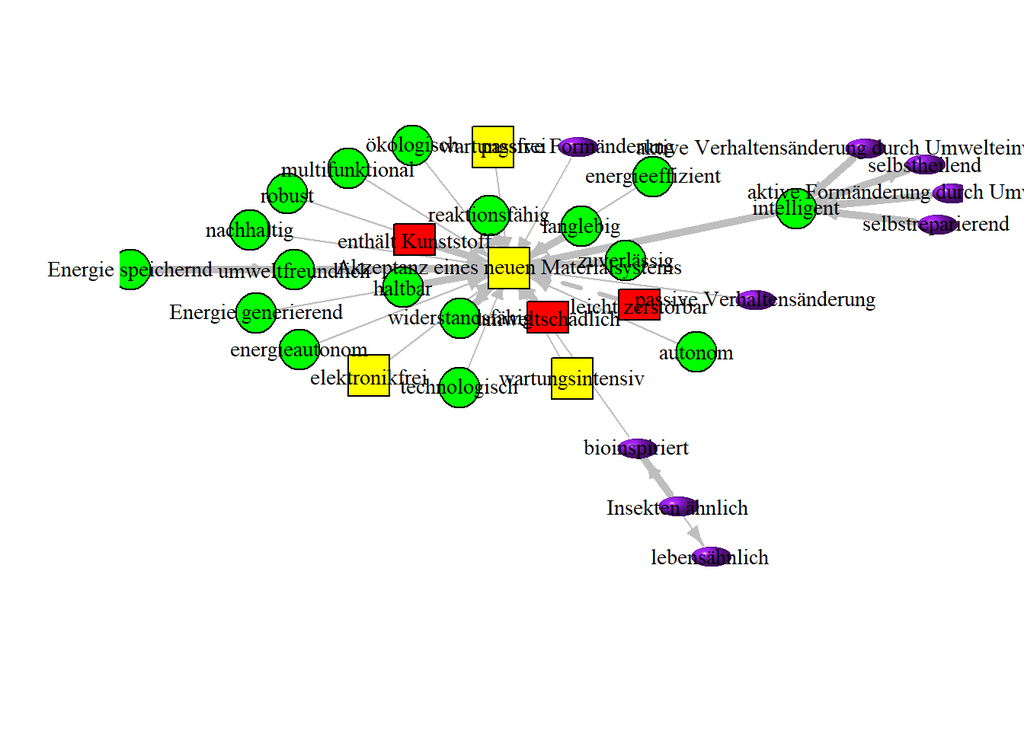

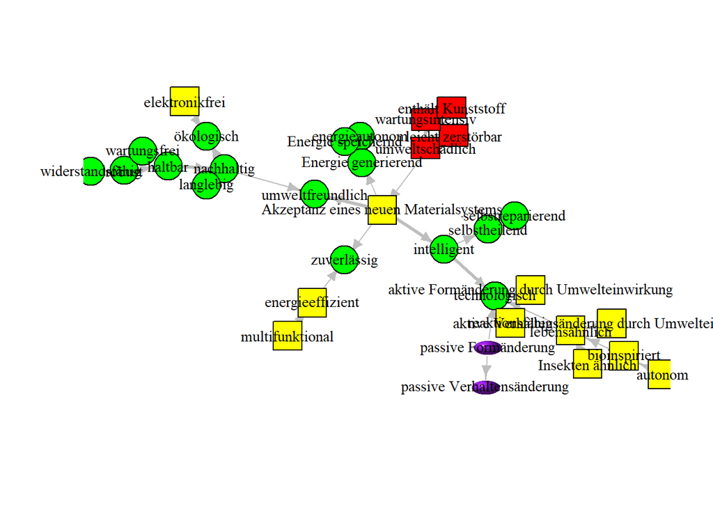

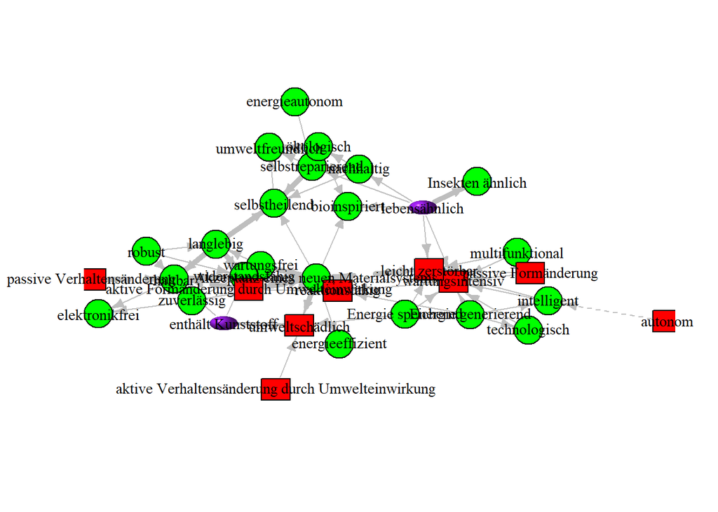

```r
for(i in 1:10){ # length(CAMdrawn)
  plot(CAMdrawn[[i]], edge.arrow.size = .7,
       layout=layout_nicely, vertex.frame.color="black", asp = .5, margin = -0.1,
       vertex.size = 10, vertex.label.cex = .9)
}
```

### plot aggregated CAM

```r
sel_ids <- unique(CAMfiles[[1]]$participantCAM)
CAMaggregated <- aggregate_CAMs(dat_merged = CAMfiles[[3]], dat_nodes = CAMfiles[[1]],
                                ids_CAMs = sel_ids)
```

```
[1] "aggregate_CAMs: using participant CAM ids"
processing 10 CAMs...
[1] "== participantCAM in drawnCAM"
```

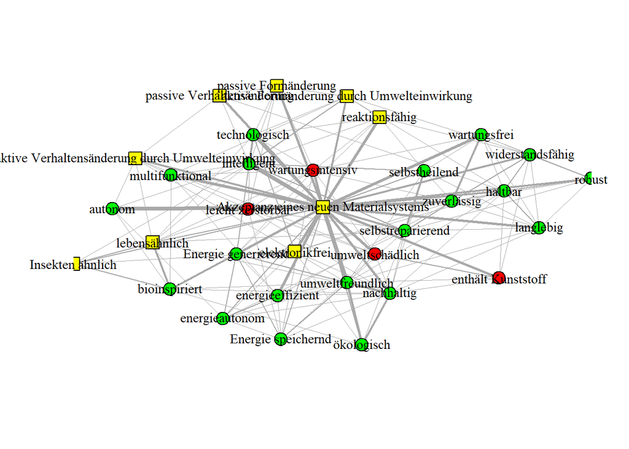

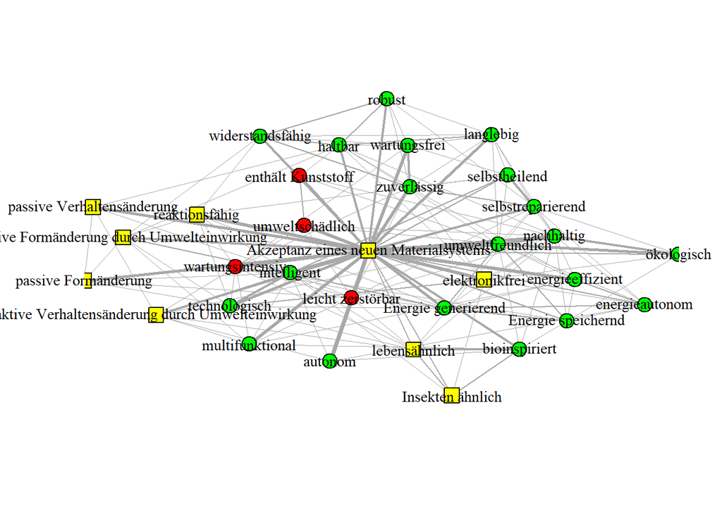

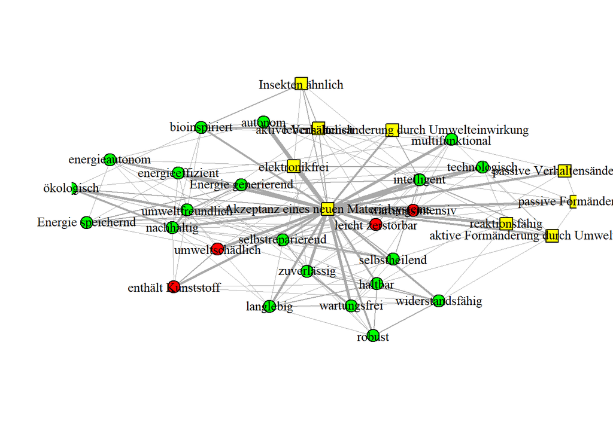

```r
# plot(CAMaggregated[[2]], vertex.size=diag(CAMaggregated[[1]]) / max(diag(CAMaggregated[[1]]))*20, edge.arrow.size=0.01)
# plot(CAMaggregated[[2]], vertex.size=(abs(V(CAMaggregated[[2]])$value)+1)*5, edge.arrow.size=0.01)


g = CAMaggregated[[2]]
g2 = simplify(CAMaggregated[[2]])
# plot(g2, edge.arrow.size=0.01,
#      vertex.size=diag(CAMaggregated[[1]]) / max(diag(CAMaggregated[[1]]))*20)

E(g2)$weight = sapply(E(g2), function(e) {
  length(all_shortest_paths(g, from=ends(g2, e)[1], to=ends(g2, e)[2])$res) } )
E(g2)$weight = E(g2)$weight * 2
# E(g2)$weight[E(g2)$weight == 1] <- NA

V(g2)$color[V(g2)$value <= .5 & V(g2)$value >= -.5] <- "yellow"

V(g2)$shape <- NA
V(g2)$shape <- ifelse(test = V(g2)$color == "yellow", yes = "square", no = "circle")



### > plot multiple times because of random layout
for(i in 1:3){
  plot(g2, edge.arrow.size = 0,
     layout=layout_nicely, vertex.frame.color="black", asp = .5, margin = -0.1,
     vertex.size=diag(CAMaggregated[[1]]) / max(diag(CAMaggregated[[1]]))*5,
     vertex.label.cex = .9,
     edge.weight=2, edge.width=(E(g2)$weight/3))
}
```

### save CAMs as .json files, and as .png (igraph)

```r
save_CAMs_as_pictures = FALSE

if(save_CAMs_as_pictures){
  setwd("outputs")

setwd("savedCAMs")
setwd("png")
### remove all files if there are any
if(length(list.files()) >= 1){
  file.remove(list.files())
  cat('\n!
      all former .png files have been deleted')
}

### if no participant ID was provided replace by randomly generated CAM ID

if(all(CAMfiles[[3]]$participantCAM.x == "noID")){
  CAMfiles[[3]]$participantCAM.x <- CAMfiles[[3]]$CAM.x
}

### save as .json files, and as .png (igraph)
ids_CAMs <- unique(CAMfiles[[3]]$participantCAM.x); length(ids_CAMs)


for(i in 1:length(ids_CAMs)){
  save_graphic(filename = paste0(ids_CAMs[i]))
  CAM_igraph <- CAMdrawn[[c(1:length(CAMdrawn))[
    names(CAMdrawn) == paste0(unique(CAMfiles[[3]]$participantCAM.x)[i])]]]
  plot(CAM_igraph, edge.arrow.size = .7,
       layout=layout_nicely, vertex.frame.color="black", asp = .5, margin = -0.1,
       vertex.size = 10, vertex.label.cex = .9)
  dev.off()
}

setwd("../json")
### remove all files if there are any
if(length(list.files()) >= 1){
  file.remove(list.files())
  cat('\n!
      all former .json files have been deleted')
}
for(i in 1:length(raw_CAM)){
  if(!is_empty(raw_CAM[[i]]$nodes)){
    if(nrow(raw_CAM[[i]]$nodes) > 5){
      write(toJSON(raw_CAM[[i]], encoding = "UTF-8"),
            paste0(raw_CAM[[i]]$idCAM, ".json"))
    }
  }
}
}
```

# analyze data

## describe data set

### feedback to the study

Question:

```r
DT::datatable(questionnaire[,c("PROLIFIC_PID", "feedback_critic")], options = list(pageLength = 5))
```

|  | PROLIFIC_PID | feedback_critic |
| --- | --- | --- |
| 1 | 65ca2cc88421b3485ac399e1 |  |
| 2 | 646b532cb1e279870b4f4c84 |  |
| 3 | 6489815c8749e9c0ea5f9ca2 |  |
| 4 | 65c8d49979ffe418b57e7220 |  |
| 5 | 5f75986c7befb820e5497fe2 | - |
| 6 | 65006fca057c310287d759a1 | Den Begriff des Materialsystems eventuell etwas mehr zu erklären. |
| 7 | 652680aaf06124cc46807a30 |  |
| 8 | 63527b6ac05d24b7ed53365a |  |
| 9 | 5fd206b9aa0fbf249adf4280 |  |
| 10 | 604b169fe4b7991ec08da3a6 |  |

### Material system that has been thought of

Question: Bitte beschreiben Sie an an welches Materialsystem oder welche Materialsysteme Sie dabei gedacht haben.

```r
DT::datatable(questionnaire[,c("PROLIFIC_PID", "openQuestion_MaterialSystem")], options = list(pageLength = 5))
```

|  | PROLIFIC_PID | openQuestion_MaterialSystem |
| --- | --- | --- |
| 1 | 65ca2cc88421b3485ac399e1 | Das ideale Materialsystem sollte vor allem ein Material sein, das keine Energie benötigt, seine eigene Energie erzeugt und speichert, wartungsfrei ist, sehr lange verwendet werden kann und der Umwelt … |
| 2 | 646b532cb1e279870b4f4c84 | Sensoren, Klimatechnik mit erhöhten Wirkungsgraden und aktiv formveränderbare Materialien |
| 3 | 6489815c8749e9c0ea5f9ca2 | An ein sich nachhaltiges der umweltanpassendes Material das Multifunktional in allen Lebensbereichen eingesetzt werden könnte, sofern diese erforscht wird! |
| 4 | 65c8d49979ffe418b57e7220 | Aerogels, Cellulose Nanofibers |
| 5 | 5f75986c7befb820e5497fe2 | ich habe an ein biobasiertes Insekten ähnliches Konstruktionsmaterial gedacht was sich für den Hausbau eignet, aber auch für andere Bereiche nutzen lässt. |
| 6 | 65006fca057c310287d759a1 | An einen neuen "Wunderverbundstoff", aus dem sowohl ein Gegenstand gefertigt sein kann, das Äußere, welcher aber auch die Funktion des Gegenstandes übernimmt. Beispielsweise kann man daraus einen Akku… |
| 7 | 652680aaf06124cc46807a30 | Außenbeschichtungen/Außenmaterial bei Fahrzeugen |
| 8 | 63527b6ac05d24b7ed53365a | Technische Materialsysteme |
| 9 | 5fd206b9aa0fbf249adf4280 | Habe an nicht konkretes gedacht, sondern die Aufgabe abstrakt gelöst, so das dies auf jedes Materialsystem passt |
| 10 | 604b169fe4b7991ec08da3a6 | biotopische materialsysteme, blätter, äste, algen |

### basal attributes: most pos. / neg.

Question: Welche drei Begriffen nehmen Sie am positivsten bzw. negativsten für die Beschreibung neuer Materialsysteme wahr?

```r
## most positive
tmp <- str_trim(unlist(str_split(string = questionnaire$multiplePositive, pattern = "\\\\")))
sort(table(tmp))
```

```
tmp
        bioinspiriert Energie   generierend        energieautonom
                    1                     1                     1
          intelligent                robust            nachhaltig
                    1                     1                     2
    selbstreparierend               haltbar             langlebig
                    2                     3                     3
           ökologisch      energieeffizient      umweltfreundlich
                    4                     5                     6
```

```r
## most negative
tmp <- str_trim(unlist(str_split(string = questionnaire$multipleNegative, pattern = "\\\\")))
sort(table(tmp))
```

```
tmp
                          Insekten ähnlich
                                         1
aktive Formänderung durch Umwelteinwirkung
                                         2
                        enthält Kunststoff
                                         4
                         leicht zerstörbar
                                         7
                          wartungsintensiv
                                         7
                           umweltschädlich
                                         9
```

```r
## answers of participants
DT::datatable(questionnaire[,c("PROLIFIC_PID", "multiplePositive", "multipleNegative")], options = list(pageLength = 5))
```

|  | PROLIFIC_PID | multiplePositive | multipleNegative |
| --- | --- | --- | --- |
| 1 | 65ca2cc88421b3485ac399e1 | energieautonom \ energieeffizient \ Energie generierend | aktive Formänderung durch Umwelteinwirkung \ umweltschädlich \ enthält Kunststoff |
| 2 | 646b532cb1e279870b4f4c84 | haltbar \ intelligent \ nachhaltig | umweltschädlich \ leicht zerstörbar \ wartungsintensiv |
| 3 | 6489815c8749e9c0ea5f9ca2 | ökologisch \ energieeffizient \ umweltfreundlich | umweltschädlich \ leicht zerstörbar \ wartungsintensiv |
| 4 | 65c8d49979ffe418b57e7220 | energieeffizient \ umweltfreundlich \ langlebig | umweltschädlich \ enthält Kunststoff \ Insekten ähnlich |
| 5 | 5f75986c7befb820e5497fe2 | bioinspiriert \ haltbar \ ökologisch | umweltschädlich \ enthält Kunststoff \ wartungsintensiv |
| 6 | 65006fca057c310287d759a1 | energieeffizient \ umweltfreundlich \ robust | umweltschädlich \ leicht zerstörbar \ wartungsintensiv |
| 7 | 652680aaf06124cc46807a30 | umweltfreundlich \ selbstreparierend \ langlebig | umweltschädlich \ leicht zerstörbar \ wartungsintensiv |
| 8 | 63527b6ac05d24b7ed53365a | ökologisch \ energieeffizient \ umweltfreundlich | umweltschädlich \ enthält Kunststoff \ leicht zerstörbar |
| 9 | 5fd206b9aa0fbf249adf4280 | umweltfreundlich \ nachhaltig \ langlebig | umweltschädlich \ leicht zerstörbar \ wartungsintensiv |
| 10 | 604b169fe4b7991ec08da3a6 | haltbar \ ökologisch \ selbstreparierend | aktive Formänderung durch Umwelteinwirkung \ leicht zerstörbar \ wartungsintensiv |

**any basal attributes missing?**

Question: Fallen Ihnen weitere Eigenschaften ein, die Sie als relevant oder negativ für die Beschreibung neuer Materialsysteme erachten, die in der Liste nicht aufgeführt sind, so können Sie diese gerne in folgenden Textfeldern ergänzen:

```r
## answers of participants
DT::datatable(questionnaire[,c("PROLIFIC_PID", "openQuestion_missedPositive", "openQuestion_missedNegative")], options = list(pageLength = 5))
```

|  | PROLIFIC_PID | openQuestion_missedPositive | openQuestion_missedNegative |
| --- | --- | --- | --- |
| 1 | 65ca2cc88421b3485ac399e1 |  |  |
| 2 | 646b532cb1e279870b4f4c84 | kostengünstig, leicht zu beschaffen | sozial unverträglich |
| 3 | 6489815c8749e9c0ea5f9ca2 |  |  |
| 4 | 65c8d49979ffe418b57e7220 |  |  |
| 5 | 5f75986c7befb820e5497fe2 | langlebig, technologisch, umweltfreundlich | - |
| 6 | 65006fca057c310287d759a1 | Nicht nur umweltfreundlich, aber auch gut recyclebar. |  |
| 7 | 652680aaf06124cc46807a30 |  |  |
| 8 | 63527b6ac05d24b7ed53365a | wiederstandfähig, multifunktional, Energie speichernd | wartungsintensiv |
| 9 | 5fd206b9aa0fbf249adf4280 |  |  |
| 10 | 604b169fe4b7991ec08da3a6 |  |  |

### basal attributes: ethical most relevant

Question: Welche drei Begriffe sind aus Ihrer Sicht in moralischer Hinsicht am “relevantesten”?

```r
## ethical relevant
tmp <- str_trim(unlist(str_split(string = questionnaire$multipleEthic, pattern = "\\\\")))
sort(table(tmp))
```

```
tmp
Energie   generierend         selbstheilend      widerstandsfähig
                    1                     1                     1
              haltbar             langlebig       umweltschädlich
                    2                     2                     2
     energieeffizient            nachhaltig            ökologisch
                    3                     3                     6
     umweltfreundlich
                    9
```

```r
## answers of participants
DT::datatable(questionnaire[,c("PROLIFIC_PID", "multipleEthic")], options = list(pageLength = 5))
```

|  | PROLIFIC_PID | multipleEthic |
| --- | --- | --- |
| 1 | 65ca2cc88421b3485ac399e1 | ökologisch \ energieeffizient \ umweltfreundlich |
| 2 | 646b532cb1e279870b4f4c84 | ökologisch \ umweltfreundlich \ langlebig |
| 3 | 6489815c8749e9c0ea5f9ca2 | ökologisch \ umweltfreundlich \ nachhaltig |
| 4 | 65c8d49979ffe418b57e7220 | ökologisch \ umweltfreundlich \ langlebig |
| 5 | 5f75986c7befb820e5497fe2 | haltbar \ ökologisch \ energieeffizient |
| 6 | 65006fca057c310287d759a1 | umweltfreundlich \ selbstheilend \ Energie generierend |
| 7 | 652680aaf06124cc46807a30 | umweltfreundlich \ nachhaltig \ umweltschädlich |
| 8 | 63527b6ac05d24b7ed53365a | ökologisch \ energieeffizient \ umweltfreundlich |
| 9 | 5fd206b9aa0fbf249adf4280 | umweltfreundlich \ nachhaltig \ umweltschädlich |
| 10 | 604b169fe4b7991ec08da3a6 | haltbar \ umweltfreundlich \ widerstandsfähig |

**argument for choosen basal attributes**

Question: Bitte begründen Sie kurz die Auswahl der ethisch relevanten Begriffe:

```r
## answers of participants
DT::datatable(questionnaire[,c("PROLIFIC_PID", "openQuestion_Ethic")], options = list(pageLength = 5))
```

|  | PROLIFIC_PID | openQuestion_Ethic |
| --- | --- | --- |
| 1 | 65ca2cc88421b3485ac399e1 | Ethische Aspekte in der Materialwissenschaft, wie ökologische Verträglichkeit und Nachhaltigkeit, sind entscheidend, um die Umweltbelastung zu minimieren und Ressourcen effizient zu nutzen. Materialie… |
| 2 | 646b532cb1e279870b4f4c84 | Umweltfreundliche und langlebige, nachhaltige Materialien sind mit Blick auf ESG-Aspekte wünschenswert. |
| 3 | 6489815c8749e9c0ea5f9ca2 | Diese werden immer wichtiger um den Erhalt des Lebens auf dem Plant Erde zu erhalten. |
| 4 | 65c8d49979ffe418b57e7220 | Der Klimawandel ist ein großer Faktor in unserer Welt und Materialien, die dabei helfen, ihn zu bekämpfen, sind wichtig |
| 5 | 5f75986c7befb820e5497fe2 | alles positiv und nachhaltige Aspekte die langfristig zu weniger Leid oder Schmerz führen |
| 6 | 65006fca057c310287d759a1 | Da der Schutz der Welt in der wir leben das für die Zukunft wohl wichtigste Thema für ein gesundes und ethisch vertretbares Fortbestehen der Menschheit ist, sind diese drei Begriffe für mich was ein n… |
| 7 | 652680aaf06124cc46807a30 | Materialien sollten unsere Lebensgrundlage, die Umwelt, nicht gefährden oder schädigen. Nachhaltigkeit sollte bei der Entwicklung von Materialien eine wichtige Eigenschaft sein. |
| 8 | 63527b6ac05d24b7ed53365a | Diese Eigenschaften sind aufgrund der Thema Klimawandel unbedingt erforderlich und müssen als vorrangig betrachtet werden. |
| 9 | 5fd206b9aa0fbf249adf4280 | Bei neuen Materialien sollen vor allem die Umweltauswirkung und Nachhaltigkeit betrachtet werden um zukünftige Schäden zu vermeiden |
| 10 | 604b169fe4b7991ec08da3a6 | die materialien müssen langlebig sein, damit wir nicht unsere welt zerstören und andere generationen auch resourcen zum leben haben |

### outcome questions

Question: Sollte die Entwicklung innovativer Materialsysteme mit öffentlichen Mitteln gefördert werden?

```r
table(questionnaire$outcome_research)
```

```
unsure    yes
     1      9
```

Question: Sollten die Erforschung und Entwicklung solcher innovativer Materialsysteme verboten werden?

```r
table(questionnaire$outcome_prohibition)
```

```
no
10
```

Question: Wären Sie bereit, Produkte zu kaufen, die innovative Materialsysteme enthalten?

```r
table(questionnaire$outcome_buy)
```

```
unsure    yes
     2      8
```

> if yes to previous question

Question: An welche möglichen Produkte haben Sie gedacht?

```r
## answers of participants
DT::datatable(questionnaire[,c("PROLIFIC_PID", "outcome_buy_text")], options = list(pageLength = 5))
```

|  | PROLIFIC_PID | outcome_buy_text |
| --- | --- | --- |
| 1 | 65ca2cc88421b3485ac399e1 | Außenmaterialien für Gebäude |
| 2 | 646b532cb1e279870b4f4c84 | Immobilien, Autos, Tech-Tools |
| 3 | 6489815c8749e9c0ea5f9ca2 | Alltagsgebrauchsgegenstände, Elektronik, Autos, öffentliche Verkehrsmittel usw. |
| 4 | 65c8d49979ffe418b57e7220 |  |
| 5 | 5f75986c7befb820e5497fe2 | Kunststoff alternativen auf Basis nachwachsender Rohstoffe |
| 6 | 65006fca057c310287d759a1 | An alles. Vom Kugelschreiber, welcher nicht zerbricht, über Haushaltsgeräte zu smarter Technologie. Autos, welche Kratzer oder Beulen bzw. generellen Verschleiß selber entfernen können und daher langl… |
| 7 | 652680aaf06124cc46807a30 | Oberflächenbeschichtungen |
| 8 | 63527b6ac05d24b7ed53365a | Fahrzeuge |
| 9 | 5fd206b9aa0fbf249adf4280 | nichts konkretes, bin für alles offen |
| 10 | 604b169fe4b7991ec08da3a6 |  |

## co-variation of basal attributes

Compare the probability that two concepts are connected in randomly generated networks to drawn CAMs:

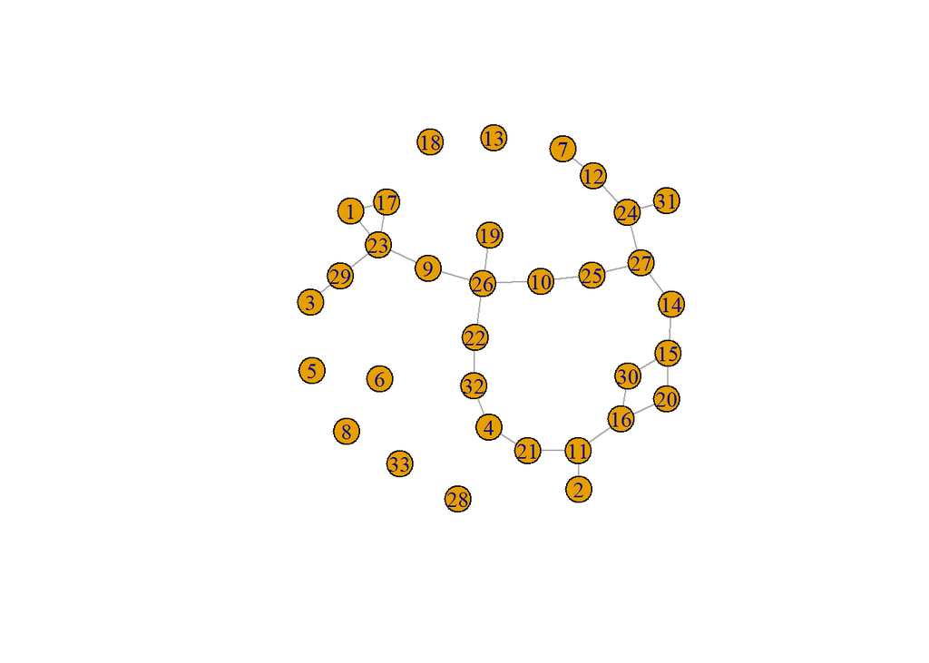

```r
## get average number of drawn concepts (here fixed)
numConcepts <- mean(networkIndicators$num_nodes_macro)
## get average density
numDensity <- mean(networkIndicators$density_macro)

## simply get the average probability that two concepts are connected:
g <- igraph::random.graph.game(n = numConcepts, p.or.m = numDensity)
plot(g)
```

```r
are.connected(g, 1, 2)
```

```
[1] FALSE
```

```
#> whereby each edge to be drawn has the identical probability in the Erdős–Rényi model
```

```r
vec_booleanConnected <- c()
# vec_booleanConnected2 <- c()

for(i in 1:10000){
  g <- igraph::random.graph.game(n = numConcepts, p.or.m = numDensity)
  vec_booleanConnected[i] <- are.connected(g, 1, 2)
    # vec_booleanConnected2[i] <- are.connected(g, 22, 26)
}
baselineProbability <- mean(vec_booleanConnected)
baselineProbability
```

```
[1] 0.0325
```

```r
# mean(vec_booleanConnected2)
```

This baseline probability can be compared to all possible combinations of drawn concepts:

```r
vec_boolean <- c()
for(i in 1:length(CAMdrawn)){
  vec_boolean[i] <- are.connected(graph = CAMdrawn[[i]],
              v1 = V(CAMdrawn[[i]])[V(CAMdrawn[[i]])$label == "robust"],
              v2 = V(CAMdrawn[[i]])[V(CAMdrawn[[i]])$label == "widerstandsfähig"])
}

mean(vec_boolean)
```

```
[1] 0.1
```